# CREscendo Tutorial: Analysis of 10X Genomics human PBMC ATAC v2 Chromium X

# Installation

To install the `CREscendo` package, you can use the code.

```r
devtools::install_github("ChenMengjie/CREscendo")
```

Then load the following libraries used in this tutorial:

```r
library(Signac)
library(Seurat)
library(EnsDb.Hsapiens.v75)
library(TxDb.Hsapiens.UCSC.hg38.knownGene)
library(CREscendo)
library(ggrepel)
library(tictoc)
```

# Dataset: 10k Human PBMCs, ATAC v2, Chromium X

We downloaded the Human PBMCs scATAC-seq dataset, which includes peak files and fragment files, from [10x Genomics](https://www.10xgenomics.com/datasets/10k-human-pbmcs-atac-v2-chromium-x-2-standard). The dataset initially contained 10,273 PBMC nuclei. We conducted quality control and cell type annotations using [Signac](https://stuartlab.org/signac/) as below.

```r
counts <- Read10X_h5(filename = "10k_pbmc_ATACv2_nextgem_Chromium_X_filtered_peak_bc_matrix.h5")
metadata <- read.csv(
  file = "10k_pbmc_ATACv2_nextgem_Chromium_X_singlecell.csv",
  header = TRUE,
  row.names = 1
)

chrom_assay <- CreateChromatinAssay(
  counts = counts,
  sep = c(":", "-"),
  fragments = '10k_pbmc_ATACv2_nextgem_Chromium_X_fragments.tsv.gz',
  min.cells = 10,
  min.features = 200
)

pbmc <- CreateSeuratObject(
  counts = chrom_assay,
  assay = "peaks",
  meta.data = metadata
)

pbmc
pbmc[['peaks']]
granges(pbmc)
# extract gene annotations from EnsDb
annotations <- GetGRangesFromEnsDb(ensdb = EnsDb.Hsapiens.v75)

# change to UCSC style since the data was mapped to hg19
seqlevels(annotations) <- paste0('chr', seqlevels(annotations))
genome(annotations) <- "hg19"

# add the gene information to the object
Annotation(pbmc) <- annotations

# compute nucleosome signal score per cell
pbmc <- NucleosomeSignal(object = pbmc)

# compute TSS enrichment score per cell
pbmc <- TSSEnrichment(object = pbmc, fast = FALSE)

# add blacklist ratio and fraction of reads in peaks
pbmc$pct_reads_in_peaks <- pbmc$peak_region_fragments / pbmc$passed_filters * 100
pbmc$blacklist_ratio <- pbmc$blacklist_region_fragments / pbmc$peak_region_fragments
pbmc$high.tss <- ifelse(pbmc$TSS.enrichment > 3, 'High', 'Low')
pbmc$nucleosome_group <- ifelse(pbmc$nucleosome_signal > 4, 'NS > 4', 'NS < 4')


pbmc <- subset(
  x = pbmc,
  subset = nCount_peaks > 3000 &
    nCount_peaks < 30000 &
    pct_reads_in_peaks > 15 &
    nucleosome_signal < 4
)

pbmc <- RunTFIDF(pbmc)
pbmc <- FindTopFeatures(pbmc, min.cutoff = 'q0')
pbmc <- RunSVD(pbmc)
pbmc <- RunUMAP(object = pbmc, reduction = 'lsi', dims = 2:30)
pbmc <- FindNeighbors(object = pbmc, reduction = 'lsi', dims = 2:30, return.neighbor = FALSE)
pbmc <- FindClusters(object = pbmc, verbose = FALSE, algorithm = 3)

gene.activities <- GeneActivity(pbmc)

pbmc[['RNA']] <- CreateAssayObject(counts = gene.activities)
pbmc <- NormalizeData(
  object = pbmc,
  assay = 'RNA',
  normalization.method = 'LogNormalize',
  scale.factor = median(pbmc$nCount_RNA)
)

DefaultAssay(pbmc) <- 'RNA'

FeaturePlot(
  object = pbmc,
  features = c('MS4A1', 'CD3D', 'LEF1', 'NKG7', 'TREM1', 'LYZ'),
  pt.size = 0.1,
  max.cutoff = 'q95',
  ncol = 3
)

# Load the pre-processed scRNA-seq data for PBMCs
pbmc_rna <- readRDS("pbmc_10k_v3.rds")
pbmc_rna <- UpdateSeuratObject(pbmc_rna)

transfer.anchors <- FindTransferAnchors(
  reference = pbmc_rna,
  query = pbmc,
  reduction = 'cca'
)

predicted.labels <- TransferData(
  anchorset = transfer.anchors,
  refdata = pbmc_rna$celltype,
  weight.reduction = pbmc[['lsi']],
  dims = 2:30
)

pbmc <- AddMetaData(object = pbmc, metadata = predicted.labels)

# replace each label with its most likely prediction
for(i in levels(pbmc)) {
  cells_to_reid <- WhichCells(pbmc, idents = i)
  newid <- names(which.max(table(pbmc$predicted.id[cells_to_reid])))
  Idents(pbmc, cells = cells_to_reid) <- newid
}
```

Or you can start with pre-processed object, which can be downloaded from [Pre-processed dataset 2](https://drive.google.com/file/d/1CtnCInRLnGcnz6wTp_hXPSpP9ZuMs_93/view?usp=share_link).

```r
load("/path/to/pbmc_ATAC_10k_v2_chromium_x_2_afterQC.rda")
pbmc
peaks.gr <- granges(pbmc@assays$peaks)
peaks.gr <- peaks.gr[grep("chr", seqnames(peaks.gr))]
peaks.gr
```

For the annotation of cis-regulatory elements (CREs), we utilized resources from the ENCODE Encyclopedia, specifically the Registry of cCREs Version 3 from [SCREEN](https://downloads.wenglab.org/V3/GRCh38-cCREs.bed). This resource details 1,063,878 candidate CREs identified by segregating signals across all biospecimen sourced from 1,518 cell types. These CREs are categorized further into candidate promoters, candidate proximal enhancers, candidate distal enhancers, and are also annotated based on their CTCF binding status.

We have implemented functions to load the CREs from the ENCODE SCREEN V3 directly.

```r
CRE_gr <- CREscendo:::load_CRE_annotations(genome = "hg38")
CRE_gr
```

```
## GRanges object with 1063878 ranges and 3 metadata columns:
##             seqnames            ranges strand |          ID1          ID2
##                <Rle>         <IRanges>  <Rle> |  <character>  <character>
##         [1]     chr1     104896-105048      + | EH38D4327509 EH38E2776520
##         [2]     chr1     138866-139134      + | EH38D4327520 EH38E2776521
##         [3]     chr1     181289-181639      + | EH38D4327525 EH38E2776524
##         [4]     chr1     267925-268171      + | EH38D4327544 EH38E2776528
##         [5]     chr1     586036-586264      + | EH38D4327554 EH38E2776532
##         ...      ...               ...    ... .          ...          ...
##   [1063874]     chrY 21252996-21253278      + | EH38D6144481 EH38E3951203
##   [1063875]     chrY 21598449-21598656      + | EH38D6144550 EH38E3951229
##   [1063876]     chrY 21839503-21839853      + | EH38D6144588 EH38E3951242
##   [1063877]     chrY 26352857-26353207      + | EH38D4327371 EH38E3951251
##   [1063878]     chrY 26353315-26353520      + | EH38D4327372 EH38E3951252
##                               type
##                        <character>
##         [1]   CTCF-only,CTCF-bound
##         [2]        pELS,CTCF-bound
##         [3] DNase-H3K4me3,CTCF-b..
##         [4]   CTCF-only,CTCF-bound
##         [5]   CTCF-only,CTCF-bound
##         ...                    ...
##   [1063874]                   dELS
##   [1063875]   CTCF-only,CTCF-bound
##   [1063876]                   dELS
##   [1063877]                   pELS
##   [1063878]                   pELS
##   -------
##   seqinfo: 24 sequences from an unspecified genome; no seqlengths
```

You can also prepare your own annotations file from other sources like the following:

```r
anno_CREs <- read.delim("/path/to/GRCh38-cCREs.bed", header = F)
CRE_gr <- GRanges(ranges=IRanges(start=anno_CREs[, 2], end=anno_CREs[, 3]),
                  seqnames=anno_CREs[, 1],
                  strand=rep("+", nrow(anno_CREs)), ID1 = anno_CREs[, 4], ID2 = anno_CREs[, 5],
                  type = anno_CREs[, 6])
CRE_gr
```

We can compare the peak sizes and the CRE sizes.

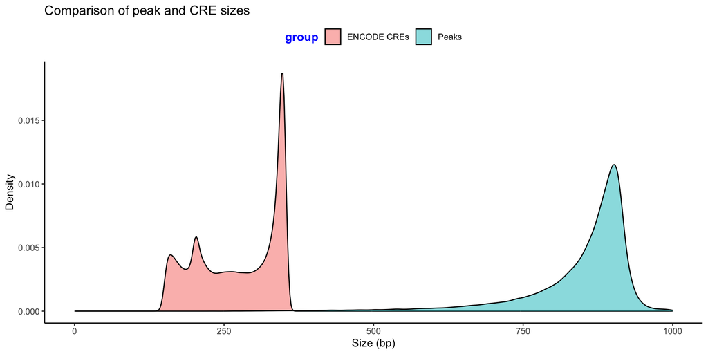

```r
peak_width <- width(peaks.gr)
CRE_width <- width(CRE_gr)
data <- data.frame(
  values = c(CRE_width, peak_width),
  group = c(rep("ENCODE CREs", length(CRE_width)),
            rep("Peaks", length(peak_width)))
)

####
pg <- ggplot(data, aes(x = values, fill = group)) +
  geom_density(alpha = 0.5, adjust = 1.2) +
  theme_classic() + xlim(0, 1000)+
  labs(title = "Comparison of peak and CRE sizes", x = "Size (bp)", y = "Density") +
  theme(legend.title = element_text(color = "blue", size = 12, face = "bold"),
        legend.position = "top")
pg
```

## Creating a CREscendo Test Data Object

In the `CREscendo` test, Tn5 cleavage frequencies are used as the input. However, this information is not readily available in the peak file alone. To obtain Tn5 cleavage data, we need to screen the fragment files. Given that these fragment files are typically quite large, we opt for the Tabix-indexed file format. Tabix files are compressed and indexed, allowing for efficient data retrieval.

The `PrepareCREscendoObject` function serves as our tool for constructing a CREscendo object. This involves several steps:

1. **Processing and annotating Genomic Peaks**: Initially, we process genomic peaks, which are typically stored in a GenomicRanges object (`peaks_gr`).
2. **Associating Peaks with CREs**: We associate these peaks with cis-regulatory elements (CREs), thereby establishing their regulatory context.
3. **Compiling Cleavage Site Counts**: The core aspect of the process involves compiling counts of cleavage sites. This requires accessing the Tabix-indexed file (`tabix_file`) containing relevant fragment data.

The `PrepareCREscendoObject` function expects the following inputs:

- `peaks_gr`: GenomicRanges object containing genomic peak locations.
- `tabix_file`: Path to a Tabix-indexed file containing fragments relevant to the peaks.
- `cell_annotation`: Data frame containing cell annotations with columns for cell name and cell type.
- `celltype_list` (Optional): A vector of cell types to include in the analysis. If NULL, all unique cell types from `cell_annotation` will be used.
- `CRE_gr`: GenomicRanges object for cis-regulatory elements.
- `tssRegion`: Numeric vector of length 2 specifying the region around transcription start sites to consider for annotation (defaults to c(-1000, 1000)).
- `TxDb`: A TxDb object containing transcript annotations.
- `annoDb`: Character string, the Bioconductor annotation package for organism-specific data. Default is “org.Hs.eg.db” for human.
- `multiCREs`: Logical value indicating whether to include peaks with multiple CREs (TRUE) or all peaks (FALSE). Default is TRUE.

This function streamlines the process, allowing for efficient preparation and construction of the necessary data object for the CREscendo test.

We applied `PrepareCREscendoObject` to extract Tn5 cleavage sites for selected cell types this dataset.

```r
cells <- colnames(x = pbmc@assays$peaks)
cell_type_list <- c("CD14+ Monocytes", "CD4 Memory", "CD8 effector", "NK dim")
cell_annotation <- data.frame(celltype = pbmc@active.ident[pbmc@active.ident%in%cell_type_list],
                              cellname = cells[pbmc@active.ident%in%cell_type_list])
head(cell_annotation)
```

```
##                           celltype           cellname
## AAACGAAAGACTAGCG-1      CD4 Memory AAACGAAAGACTAGCG-1
## AAACGAAAGCAACGGT-1      CD4 Memory AAACGAAAGCAACGGT-1
## AAACGAAAGGATTAAC-1      CD4 Memory AAACGAAAGGATTAAC-1
## AAACGAAAGGGTCCCT-1      CD4 Memory AAACGAAAGGGTCCCT-1
## AAACGAACAAACGACG-1 CD14+ Monocytes AAACGAACAAACGACG-1
## AAACGAACATTCTTTG-1 CD14+ Monocytes AAACGAACATTCTTTG-1
```

The fragment and itself index files were downloaded from [10x Genomics](https://www.10xgenomics.com/datasets/10k-human-pbmcs-atac-v2-chromium-x-2-standard).

[output not shown]

[output not shown]

```r
tbx.path <- "/path/to/10k_pbmc_ATACv2_nextgem_Chromium_X_fragments.tsv.gz"
index.path <- "/path/to/10k_pbmc_ATACv2_nextgem_Chromium_X_fragments.tsv.gz.tbi"

tabix.file <- TabixFile(
  file = tbx.path,
  index = index.path
)
open(con = tabix.file)

cell_type_list <- c("CD14+ Monocytes", "CD4 Memory", "CD8 effector", "NK dim")

pbmc_CREscendo <- PrepareCREscendoObject(peaks.gr, tabix.file, cell_annotation, cell_type_list,
      CRE_gr, tssRegion=c(-1000, 1000), TxDb = TxDb.Hsapiens.UCSC.hg38.knownGene, annoDb =  "org.Hs.eg.db")
```

Tn5 cleavage sites are identified by using the start and end sites of each segment from fragment files. We annotate each peak using ENCODE-defined CREs. For peaks with k overlapping CREs, we divide the peak into k+1 segments (cre1, cre2, …, crek) plus an additional segment for base pairs within the peak not covered by any CREs. For each cell type, we construct a frequency vector that represents the number of cleavage sites falling within each segment. The final CREscendo object contains annotated peaks, CRE associations, and cleavage event counts for further analysis.

## Testing CRE Association with specified cell types within a CREscendo Object

The main function `CREtest()` performs chi-squared tests on CREs associated with peaks within a CREscendo object. It evaluates differential CRE activities between two groups of cells.

The required input includes: - `x`: A CREscendo object containing the necessary datasets for CRE analysis. - `celltypes`: One or two cell types. Must be cell types included in the CREscendo object. If one cell type is specified, the comparison will be made between the specified cell type and all other cell types. If two cell types are specified, the comparison will be made between the two specified cell types.

For each peak, we perform a chi-square test with degrees of freedom equal to k (k is the number of overlapping CREs). In the chi-square tests for comparison, with two cell types A and B, we conduct the test first using A as the reference population, and then repeat using B. The final p-value is determined as the maximum (less significant) from these two tests. After generating test statistics for all peaks, we apply false discovery rate (FDR) adjustments to correct for multiple comparisons. We further quantified the contribution of CRE by breaking down the overall chi-square statistic into partial chi-square statistic from each CRE.

As an exmaple, we performed the CREscendo test between CD14 Mono and CD4 Memory cells in PBMC ATAC V2 dataset.

```r
tic()
comparison1 <- CREtest(pbmc_CREscendo, celltypes = c("CD14+ Monocytes", "CD4 Memory"))
toc()
```

```
## 1345.773 sec elapsed
```

```r
comparison1_summary <- Summarize(comparison1)
head(comparison1_summary)
```

```
##                          chisq_stat fdr max_contribution max_refID   max_dif
## chr21-46550159-46551101    21729.50   0         93.48016         1 0.9371743
## chr2-10043897-10044759     20871.85   0         85.38484         1 0.9087956
## chr8-81130499-81131254     17467.04   0         99.09455         1 0.9857410
## chr1-160629141-160629963   16064.77   0         88.49040         1 0.8806368
## chr20-63635447-63636203    14387.53   0         91.66791         1 0.8670240
## chr11-1850489-1851291      14166.92   0         90.82576         1 0.8691856
##                            abs_dif  n_1  n_2 df1
## chr21-46550159-46551101  0.7724216  168 1917   3
## chr2-10043897-10044759   0.4869433  926 5194   3
## chr8-81130499-81131254   0.4431473  156  565   3
## chr1-160629141-160629963 0.6148160  108 3134   4
## chr20-63635447-63636203  0.5392607  133 3751   3
## chr11-1850489-1851291    0.6040379 1144 3206   3
##                                                 CRE_type seqnames     start
## chr21-46550159-46551101                        dELS;dELS    chr21  46550159
## chr2-10043897-10044759    PLS,CTCF-bound;pELS,CTCF-bound     chr2  10043897
## chr8-81130499-81131254                         dELS;dELS     chr8  81130499
## chr1-160629141-160629963       dELS;dELS,CTCF-bound;dELS     chr1 160629141
## chr20-63635447-63636203             dELS,CTCF-bound;dELS    chr20  63635447
## chr11-1850489-1851291    dELS,CTCF-bound;pELS,CTCF-bound    chr11   1850489
##                                end width strand
## chr21-46550159-46551101   46551101   943      *
## chr2-10043897-10044759    10044759   863      *
## chr8-81130499-81131254    81131254   756      *
## chr1-160629141-160629963 160629963   823      *
## chr20-63635447-63636203   63636203   757      *
## chr11-1850489-1851291      1851291   803      *
##                                                               annotation
## chr21-46550159-46551101    Exon (ENST00000417564.3/23181, exon 23 of 38)
## chr2-10043897-10044759                                          Promoter
## chr8-81130499-81131254                                 Distal Intergenic
## chr1-160629141-160629963 Intron (ENST00000302035.11/6504, intron 3 of 6)
## chr20-63635447-63636203                                Distal Intergenic
## chr11-1850489-1851291                                             5' UTR
##                          geneChr geneStart   geneEnd geneLength geneStrand
## chr21-46550159-46551101       21  46552911  46558738       5828          1
## chr2-10043897-10044759         2  10044175  10047755       3581          1
## chr8-81130499-81131254         8  81149107  81159534      10428          1
## chr1-160629141-160629963       1 160610765 160646958      36194          2
```

[output cut: 8 more lines]

```
## chr11-1850489-1851291         4046 ENST00000311604.8         -1793
##                                  ENSEMBL       SYMBOL
## chr21-46550159-46551101  ENSG00000160305        DIP2A
## chr2-10043897-10044759   ENSG00000172059        KLF11
## chr8-81130499-81131254   ENSG00000253214 LOC105375924
## chr1-160629141-160629963 ENSG00000117090       SLAMF1
## chr20-63635447-63636203  ENSG00000232442       MHENCR
## chr11-1850489-1851291    ENSG00000130592         LSP1
##                                                                                               GENENAME
## chr21-46550159-46551101                                          disco interacting protein 2 homolog A
## chr2-10043897-10044759                                                     KLF transcription factor 11
## chr8-81130499-81131254                                                    uncharacterized LOC105375924
## chr1-160629141-160629963                     signaling lymphocytic activation molecule family member 1
## chr20-63635447-63636203  melanoma highly expressed competing endogenous lncRNA for miR-425 and miR-489
## chr11-1850489-1851291                                                    lymphocyte specific protein 1
```

To refine our results from the chi-squared test, we can utilize the `Filter()` function. This function is designed to extract and return high-confidence results from the summary component of the chi-squared test, enabling prioritized downstream analysis. The `Filter()` function accepts the following parameters:

- `x`: A CREscendoTested object containing the results from CRE association tests.
- `fdr_cutoff`: A numeric value specifying the false discovery rate (FDR) adjusted p-value threshold for filtering the results. The default is 0.05.
- `coverage_cutoff`: A numeric value specifying the cutoff of the number of fragments across all cells within the same type for each peak region for filtering the results. The default is 100.
- `abs_diff_cutoff`: A numeric value specifying the cutoff of the absolute difference in the CRE frequencies between two cell types. The default is 0.2. By applying these filtering criteria, we can focus our analysis on the most significant relevant CRE associations.

```r
comparison1_summary <- Filter(comparison1)
```

## Visualization of CREscendo Test Results

The function `Visualize()` is designed to visualize cleavage sites of different cell types for a specific peak or peaks from a specific gene within a `CREscendoTested` object. This function facilitates the extraction and visualization of relevant data, including cleavage sites, CRE annotations, and CRE frequencies within tested cell types.

The following is a visualization of the CREscendo test results for a specific peak (chr11-66317739-66318641).

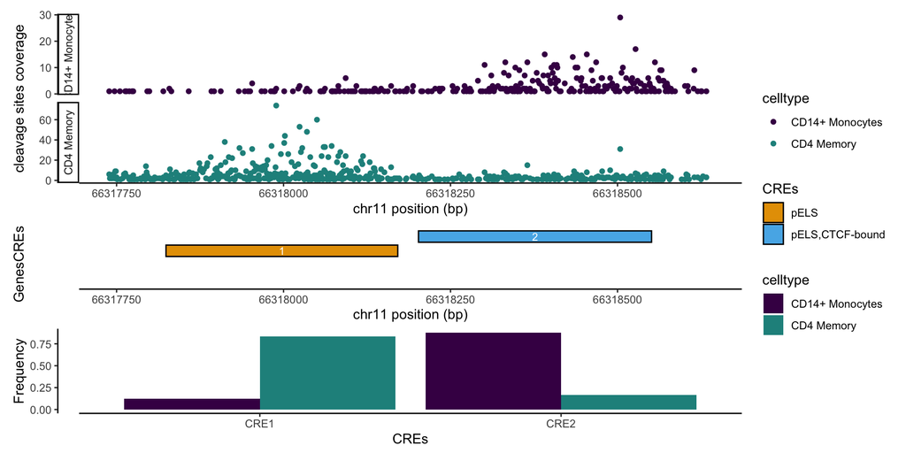

```r
Visualize(comparison1, which_peak = "chr11-66317739-66318641")
```

If you are interested in a specific peak, like the contribution of each CRE to the chi-square statistics, you can extract more details using the `Extract()` function.

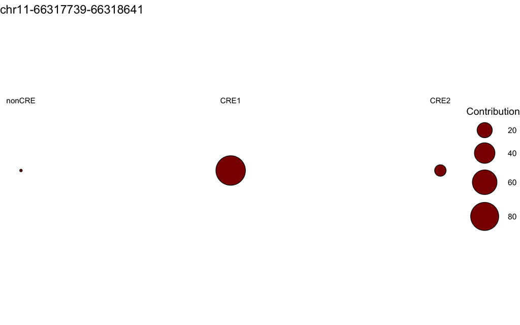

```r
info_for_a_peak <- Extract(comparison1, which_peak = "chr11-66317739-66318641")
info_for_a_peak$plot_contribution
```

```r
info_for_a_peak$annotation
```

```
##                         chisq_stat fdr max_contribution max_refID   max_dif
## chr11-66317739-66318641   12911.77   0         89.22495         1 0.8629605
##                           abs_dif n_1  n_2 df1             CRE_type seqnames
## chr11-66317739-66318641 0.6564321 825 2787   3 pELS;pELS,CTCF-bound    chr11
##                            start      end width strand annotation geneChr
## chr11-66317739-66318641 66317739 66318641   903      *   Promoter      11
##                         geneStart  geneEnd geneLength geneStrand geneId
## chr11-66317739-66318641  66314494 66317044       2551          2  57124
##                              transcriptId distanceToTSS         ENSEMBL SYMBOL
## chr11-66317739-66318641 ENST00000311330.4          -695 ENSG00000174807  CD248
##                               GENENAME
## chr11-66317739-66318641 CD248 molecule
```

The following is a visualization of the CREscendo test results for a specific gene (VAV1).

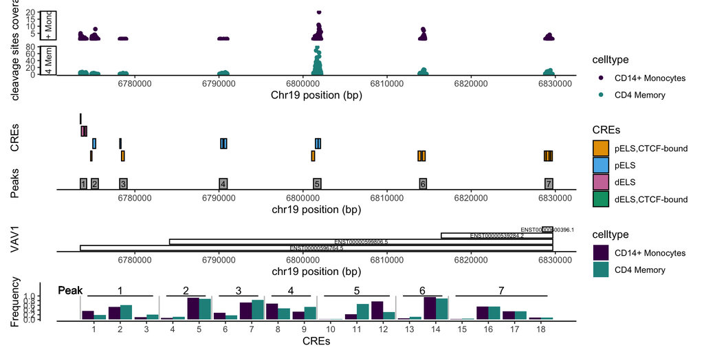

```r
Visualize(comparison1, which_gene = "VAV1")
```

Similarly, more details can be extracted.

```r
info_for_a_gene <- Extract(comparison1, which_gene = "VAV1")
info_for_a_gene$peak_annotation
```

```
##                         chisq_stat          fdr max_contribution max_refID
## chr19-6773508-6774268   20.6571557 0.0003248389         72.03521         2
## chr19-6774823-6775656    5.1854409 0.0932652588         55.12745         1
## chr19-6778189-6779075    0.6644581 0.7752808080         66.85260         2
## chr19-6790047-6790986   12.3523220 0.0045588402         75.55934         2
## chr19-6801237-6802136 3368.2259277 0.0000000000         74.50925         1
## chr19-6813869-6814679    7.8137840 0.0365836472         41.83085         2
## chr19-6828780-6829703    0.3609309 0.9935728475         76.71134         2
##                         max_dif    abs_dif n_1  n_2 df1
## chr19-6773508-6774268 0.5417349 0.15914894  94  350   4
## chr19-6774823-6775656 0.3354430 0.11826401 158   70   3
## chr19-6778189-6779075 0.3731343 0.09079602  12   67   3
## chr19-6790047-6790986 0.7529412 0.46666667  10  210   3
## chr19-6801237-6802136 0.6612743 0.41538675 377 3224   4
## chr19-6813869-6814679 0.5834334 0.11145092  98  347   3
## chr19-6828780-6829703 0.3092369 0.01891286  83  344   5
##                                                   CRE_type seqnames   start
## chr19-6773508-6774268            pELS,CTCF-bound;pELS;pELS    chr19 6773508
## chr19-6774823-6775656                 dELS;dELS,CTCF-bound    chr19 6774823
## chr19-6778189-6779075                 dELS,CTCF-bound;dELS    chr19 6778189
## chr19-6790047-6790986      dELS,CTCF-bound;dELS,CTCF-bound    chr19 6790047
## chr19-6801237-6802136 dELS;dELS,CTCF-bound;dELS,CTCF-bound    chr19 6801237
## chr19-6813869-6814679                            dELS;dELS    chr19 6813869
## chr19-6828780-6829703                  dELS;dELS;dELS;dELS    chr19 6828780
##                           end width strand
## chr19-6773508-6774268 6774268   761      *
## chr19-6774823-6775656 6775656   834      *
## chr19-6778189-6779075 6779075   887      *
## chr19-6790047-6790986 6790986   940      *
## chr19-6801237-6802136 6802136   900      *
## chr19-6813869-6814679 6814679   811      *
## chr19-6828780-6829703 6829703   924      *
##                                                            annotation geneChr
## chr19-6773508-6774268                                        Promoter      19
## chr19-6774823-6775656 Intron (ENST00000602142.6/7409, intron 1 of 26)      19
## chr19-6778189-6779075 Intron (ENST00000602142.6/7409, intron 1 of 26)      19
## chr19-6790047-6790986 Intron (ENST00000602142.6/7409, intron 1 of 26)      19
## chr19-6801237-6802136 Intron (ENST00000602142.6/7409, intron 1 of 26)      19
## chr19-6813869-6814679 Intron (ENST00000602142.6/7409, intron 1 of 26)      19
## chr19-6828780-6829703                                        Promoter      19
```

[output cut: 9 more lines]

```
## chr19-6773508-6774268 ENST00000596764.5           780 ENSG00000141968   VAV1
## chr19-6774823-6775656 ENST00000596764.5          2095 ENSG00000141968   VAV1
## chr19-6778189-6779075 ENST00000599806.5         -5043 ENSG00000141968   VAV1
## chr19-6790047-6790986 ENST00000599806.5          5929 ENSG00000141968   VAV1
## chr19-6801237-6802136 ENST00000539284.2        -14300 ENSG00000141968   VAV1
## chr19-6813869-6814679 ENST00000539284.2         -1757 ENSG00000141968   VAV1
## chr19-6828780-6829703 ENST00000600396.1           318 ENSG00000141968   VAV1
##                                                       GENENAME
## chr19-6773508-6774268 vav guanine nucleotide exchange factor 1
## chr19-6774823-6775656 vav guanine nucleotide exchange factor 1
## chr19-6778189-6779075 vav guanine nucleotide exchange factor 1
## chr19-6790047-6790986 vav guanine nucleotide exchange factor 1
## chr19-6801237-6802136 vav guanine nucleotide exchange factor 1
## chr19-6813869-6814679 vav guanine nucleotide exchange factor 1
## chr19-6828780-6829703 vav guanine nucleotide exchange factor 1
```

## Comparing with differential accessbility analysis

For the PBMC ATAC V2 dataset, we performed differential accessibility (DA) tests between different cell types. We select logistic regression for the test and include the total number of peaks as a covariate to compensate for variations in sequencing depth as recommended in Signac.

```r
DefaultAssay(pbmc) <- 'peaks'
tic()
da_peaks <- FindMarkers(
  object = pbmc,
  ident.1 = "CD14+ Monocytes",
  ident.2 = "CD4 Memory",
  test.use = 'LR',
  latent.vars = 'nCount_peaks'
)
toc()
```

```
## 3776.3 sec elapsed
```

```r
head(da_peaks)
```

```
##                          p_val avg_log2FC pct.1 pct.2 p_val_adj
## chr1-27001575-27002472       0   5.410964 0.439 0.012         0
## chr1-86774081-86774965       0   5.762311 0.428 0.009         0
## chr1-182149099-182150014     0   5.601448 0.506 0.012         0
## chr1-183604219-183605159     0   6.400467 0.433 0.007         0
## chr1-206802973-206803888     0  -6.298790 0.011 0.590         0
## chr1-221000199-221001080     0   7.424187 0.433 0.003         0
```

We further compared the results from CREscendo and DA tests.

```r
chisq_test_summary <- Summarize(comparison1)
commons <- intersect(rownames(chisq_test_summary), rownames(da_peaks))
all_stats <- cbind(chisq_test_summary[commons, ], da_peaks[commons, ])


# Updated ggplot2 code with ggrepel for non-overlapping text labels
dq <- ggplot(all_stats, aes(x = avg_log2FC, y = chisq_stat)) +
  geom_point( size = 0.8) +
  geom_text_repel(data = subset(all_stats, chisq_stat > 12000),
                  aes(label = SYMBOL),
                  max.overlaps = Inf,
                  box.padding = 0.5,
                  point.padding = 0.5,
                  size = 3,  color = 'darkred') +
  xlim(-6, 6) +  # Slightly wider x-axis limits
  ylim(min(all_stats$chisq_stat), max(all_stats$chisq_stat) + 500) +  # Extend y-axis if necessary
  theme_classic() + labs(title = "CD14+ Monocytes vs CD4 Memory", x = "Avg log2FC", y = "Chi-square statistics") +
  theme(plot.margin = margin(1, 1, 1, 1, "cm"))  # Set x-axis limits
```

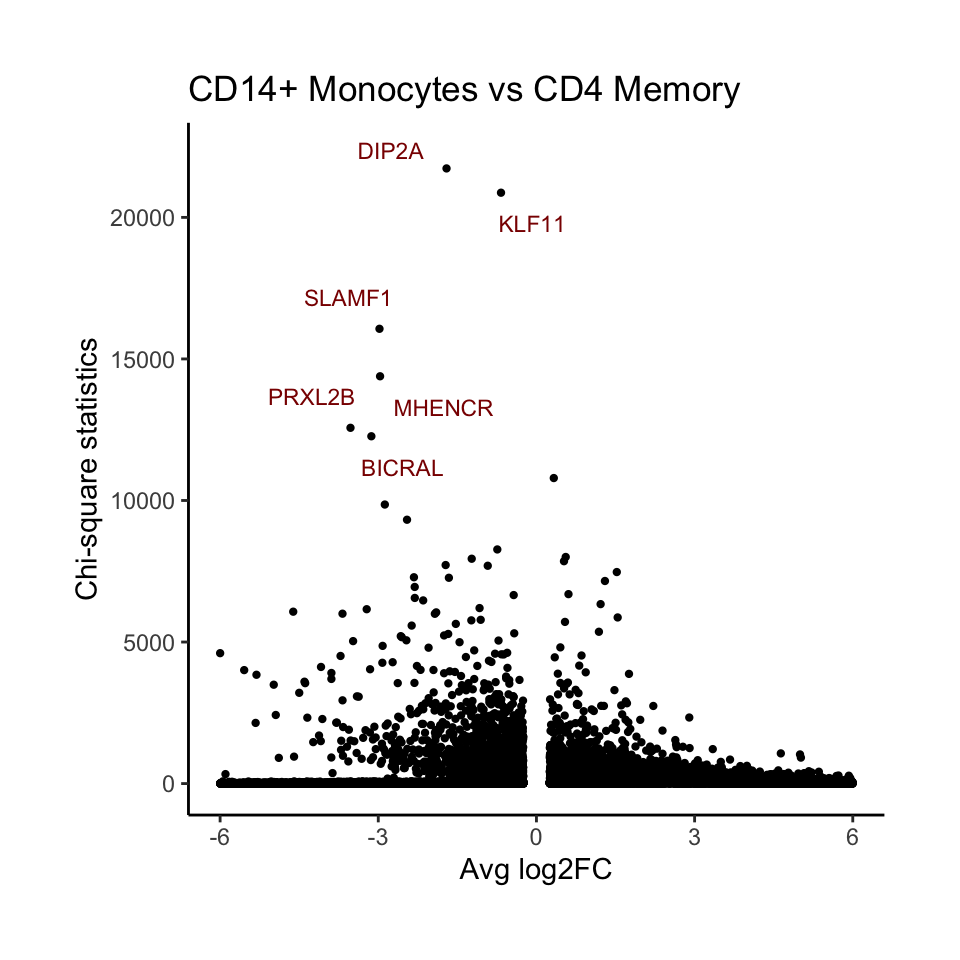

```r
dq
```